# Quantitative Methods

SKOC62: Research Methods  
in Strategic Communication 2026

nils.holmberg@iko.lu.se

## Course literature

[figure not shown]

6 and Bellamy (2011)

[figure not shown]

Trost and Hultåker (2016)

[figure not shown]

Djurfeldt, Larsson, and Stjärnhagen (2003)

## Lecture overview

- `Data collection`
- Survey, questionnaire
- Content analysis
- Process tracing
- `Descriptive analysis`
- Univariate analysis
- Visualizing variables
- `Bivariate analysis`
- Compare means
- Hypothesis testing
- Categorical variables
- Continuous variables
- `Multivariate analysis`
- Multiple regression

Data Collection

## Survey, questionnaire

- attitude measurement
- knowledge, behaviors
- self-reported data
- population, sample size
- [online experiments](https://nils-holmberg.github.io/scom-expm/web/basic/)

```
graph LR
    direction LR

    subgraph Analysis [Factors expected to influence co-workers <br/>perceived access to information]
        direction LR

        %% Independent Variables
        iv1(co-worker age)
        iv2(co-worker role)
        iv3(organization type)

        %% Dependent Variable
        dv1[[<b>co-worker <br/>perceived access <br/>to information</b>]]

        %% Connections
        iv1 --> dv1
        iv2 --> dv1
        iv3 --> dv1
    end

    %% Node Styling
    style Analysis fill:#f9f9f9,stroke:#ccc,stroke-dasharray: 5 5
    style iv1 fill:#ffffff,stroke:#333,color:#000
    style iv2 fill:#ffffff,stroke:#333,color:#000
    style iv3 fill:#ffffff,stroke:#333,color:#000
    style dv1 fill:#517699,stroke:#2b4156,color:#fff

    %% Darker Arrow Styling (Indices start at 0)
    linkStyle 0,1,2 stroke:#000,stroke-width:2px;
```

## Content analysis

- quantitative content analysis
- computational content analysis
- natural language processing
  - named entity recognition
  - sentiment analysis
- computer vision
  - emotion recognition
  - object recognition

## Process tracing

- interaction over time
- eye-tracking
- psychophysiology
- web analytics
- computer interaction

[video not shown]

## Penguins dataset

- `species` (nominal)
- `island` (nominal)
- `bill_length_mm` (cont.)
- `bill_depth_mm` (cont.)
- `flipper_length_mm` (cont.)
- `body_mass_g` (cont.)
- `sex` (binary)

```python
import pandas as pd
#import matplotlib.pyplot as plt

# Load the dataset
path = "../../csv/penguins.tsv"
dfp = pd.read_csv(path, sep="\t")

print(dfp["species"].value_counts(dropna=False))
```

```
species
Adelie       152
Gentoo       124
Chinstrap     68
Name: count, dtype: int64
```

## Theoretical model

- Download sample [dataset](https://github.com/cca-cce/osm-comm/raw/refs/heads/main/csv/penguins.tsv) and analyze model
- Perform descriptive statistics and data transformations
- `Perform bivariate analyses and hypothesis testing`
- Perform multivariate analysis, multiple regression

```
graph LR
    direction LR

    subgraph Analysis [<b>Effects on penguin body mass</b>]
        direction LR

        %% Independent Variables
        iv1(bill_length_mm)
        iv2(species)
        iv3(sex)

        %% Dependent Variable
        dv1[[<b>body_mass_g</b>]]

        %% Connections
        iv1 --> dv1
        iv2 --> dv1
        iv3 --> dv1
    end

    %% Node Styling
    style Analysis fill:#f9f9f9,stroke:#ccc,stroke-dasharray: 5 5
    style iv1 fill:#ffffff,stroke:#333,color:#000
    style iv2 fill:#ffffff,stroke:#333,color:#000
    style iv3 fill:#ffffff,stroke:#333,color:#000
    style dv1 fill:#ff8401,stroke:#2b4156,color:#fff

    %% Darker Arrow Styling (Indices start at 0)
    linkStyle 0,1,2 stroke:#000,stroke-width:2px;
```

Descriptive Analysis

## Data Types and Measurement Scales

- Dependent variable (ratio): `body_mass_g`
- `bill_length_mm` is quantitative (ratio scale)
- `species` and `sex` are categorical (nominal scale)
- Descriptive analysis starts with completeness and frequency checks

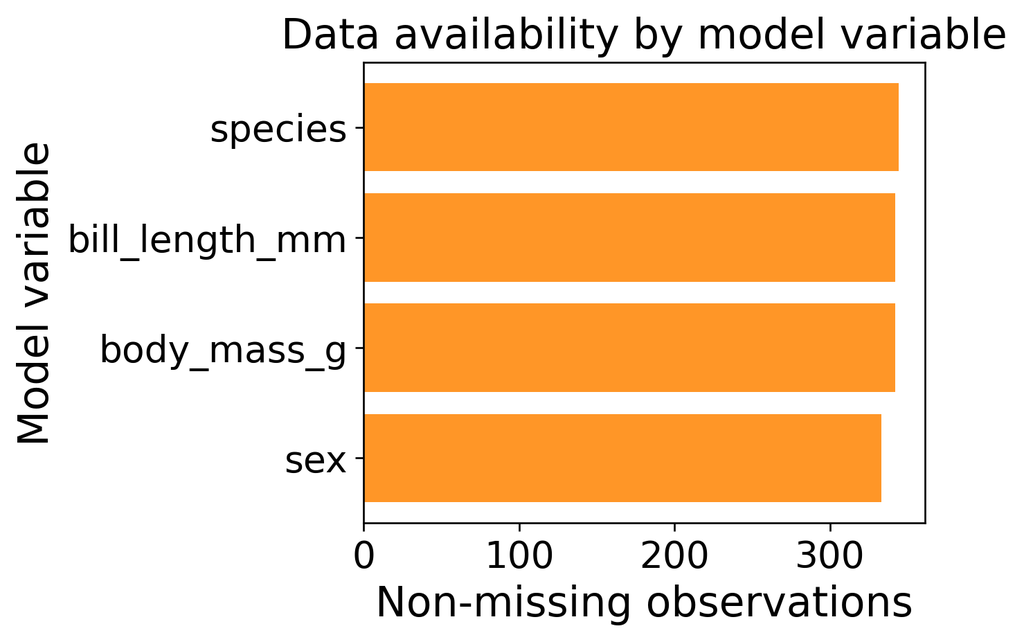

## Frequency Distributions (`species`)

- Frequency tables summarize nominal variables
- `species` distribution shows sample composition
- Group imbalance affects subgroup interpretation
- Percentages complement raw counts
- This is a first quality check before modeling

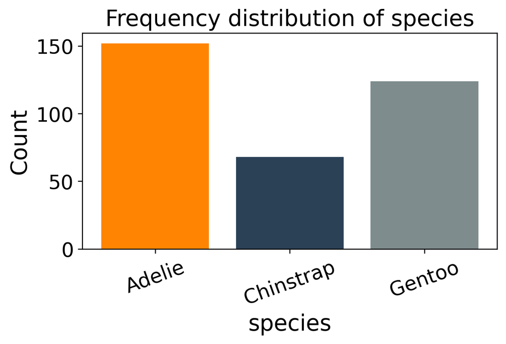

## Frequency Distributions (`sex`)

- `sex` is also nominal and summarized by counts
- Missing values matter when categories are few
- Balanced categories help cleaner comparisons
- Always report the valid `n` for subgroup analyses
- This supports later bivariate checks with `body_mass_g`

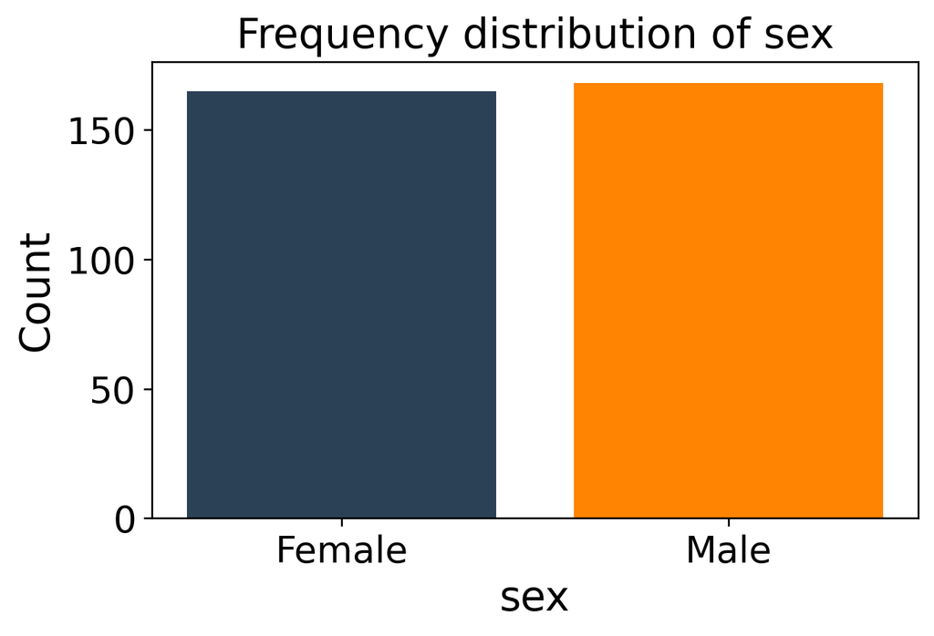

## Center and Spread (`body_mass_g`)

- Numeric descriptives summarize central tendency and spread
- This table is transposed for one variable at a time
- Mean and median show center
- Standard deviation and quartiles show dispersion
- Reported values are based on non-missing `body_mass_g`

|  | body_mass_g |
| --- | --- |
| count | 342.00 |
| mean | 4201.75 |
| std | 801.95 |
| min | 2700.00 |
| 25% | 3550.00 |
| 50% | 4050.00 |
| 75% | 4750.00 |
| max | 6300.00 |

## Distribution Shape

- Histogram shows the shape of `body_mass_g`
- Mean (solid line) and median (dashed) indicate center
- Differences between lines suggest skewness
- Spread and tails are visible beyond single summary values
- Distribution checks are a first step before modeling

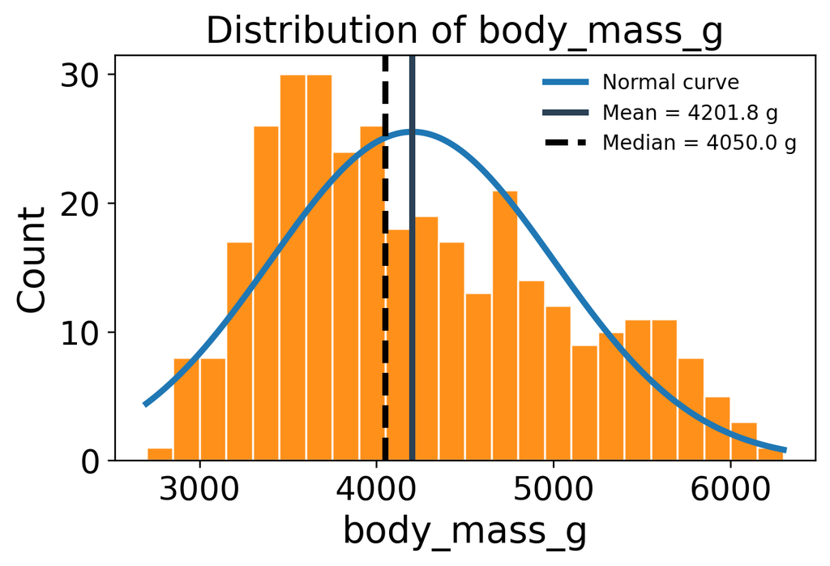

## Center, Spread, Outliers

- A boxplot summarizes median, quartiles, and spread
- The box spans Q1 to Q3 (the interquartile range, IQR)
- Whiskers extend to points within `1.5 x IQR`
- Points beyond whiskers are flagged as potential outliers
- Here we intentionally set three low values (12, 13, 14 mm)

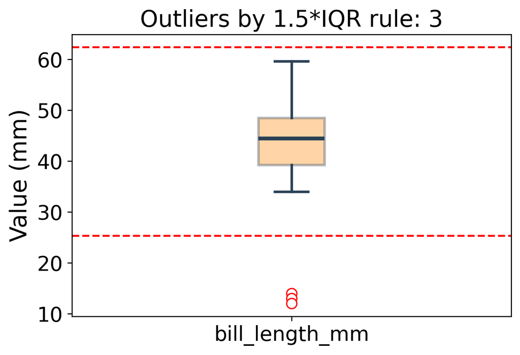

Bivariate Analysis  
and  
Hypothesis Testing

## Bivariate Analysis

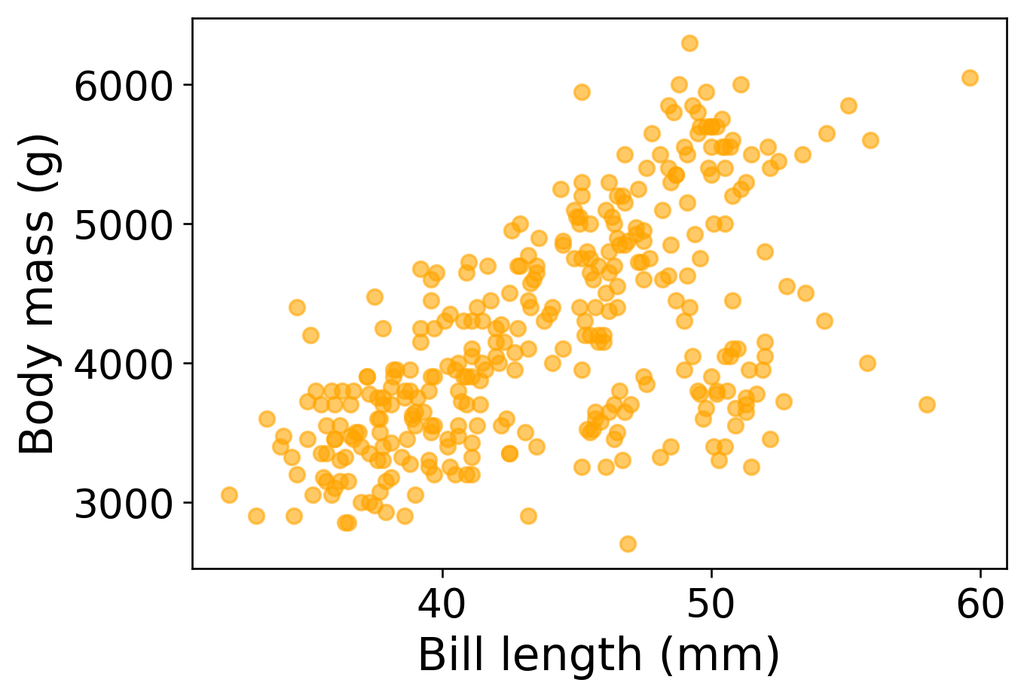

## Comparing Two Means

- Compare group averages (e.g., female vs male body mass)
- Use two-sample t-test with Welch correction
- Visualize overlap before testing
- Report group means and confidence intervals
- Consider practical significance alongside p-values

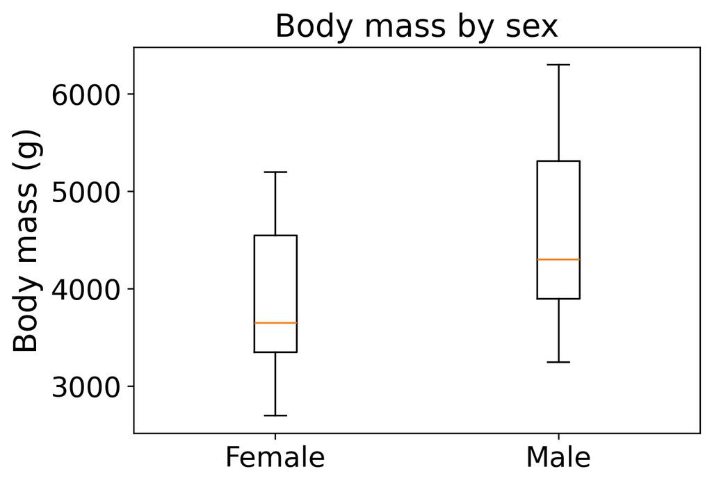

## Hypothesis Testing

- Compare means across groups (e.g., gender gaps)
- Use t-tests or nonparametric alternatives
- Emphasize effect sizes, not only p-values
- Check assumptions and sample sizes
- Interpret results in social context

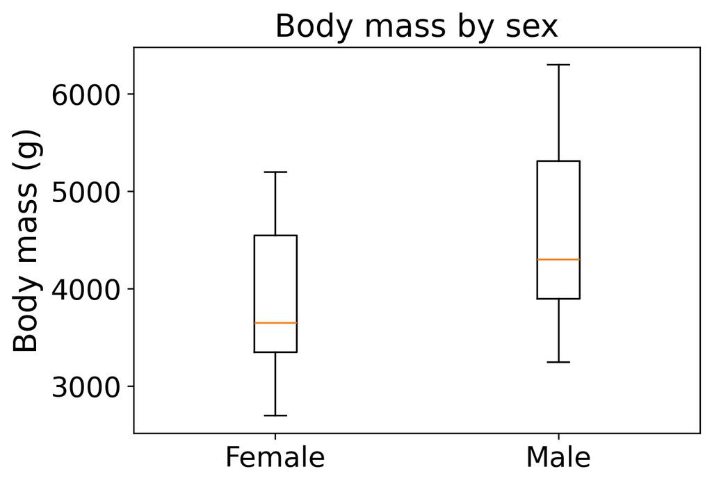

## Null Hypothesis Testing Overview

- NHST compares observed data to a null model
- The null model generates a reference distribution
- We ask: how unusual is our result under the null?
- Results depend on both effect size and sample size
- Visualization helps interpret evidence and uncertainty

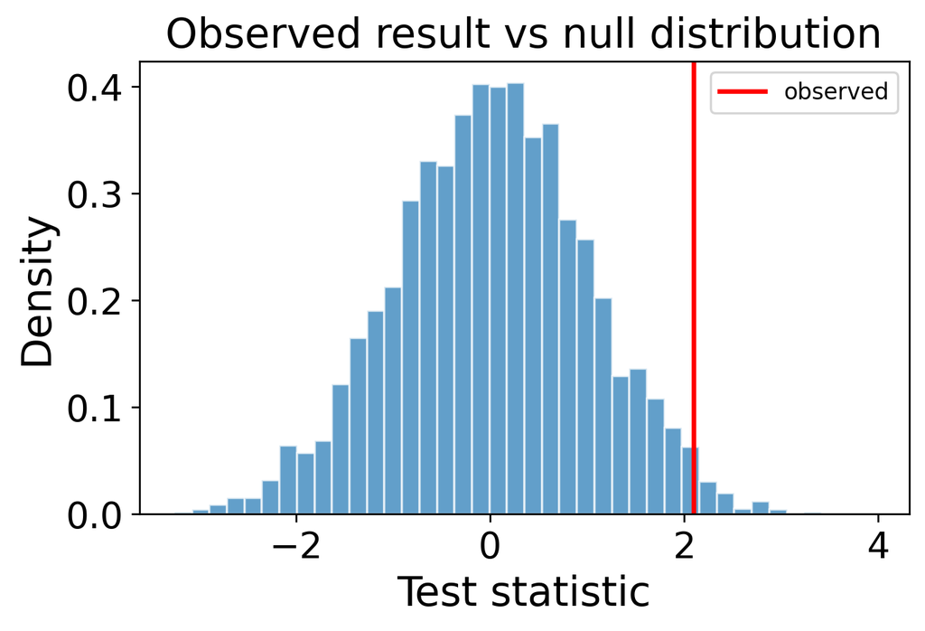

## Explore Empirical Distributions

- Collect data relevant to the hypothesis
- Choose a statistic that captures group differences
- Example: penguin body mass difference by sex
- Visualizing groups clarifies overlap and variability
- The test statistic summarizes this comparison

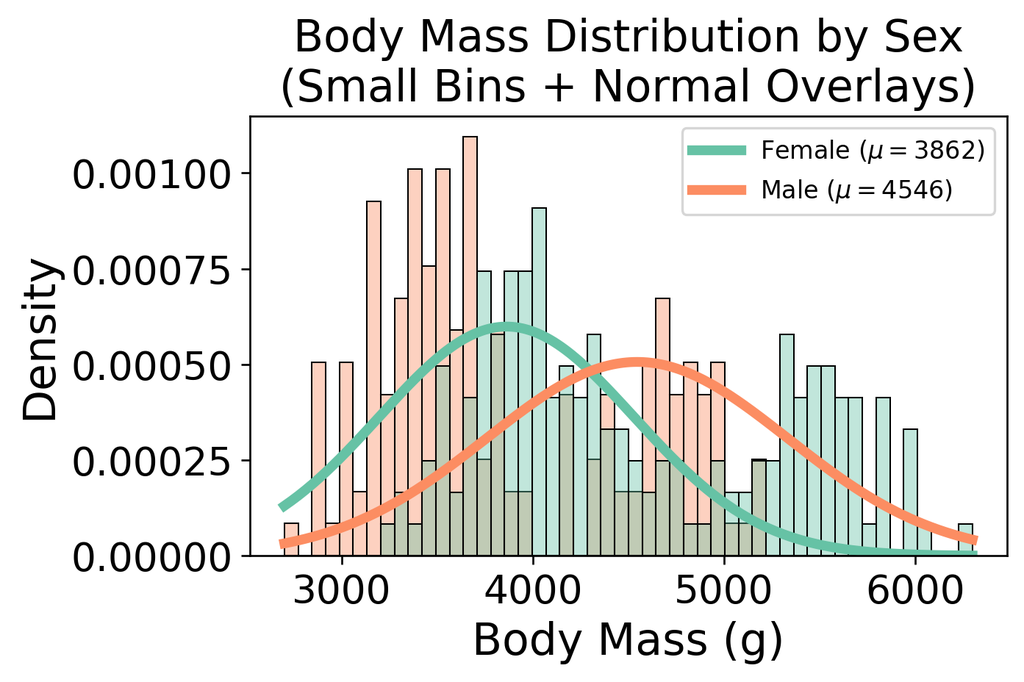

## Statistical Significance and Decision Rules

- Significance compares p-values to a preset alpha (e.g., 0.05)
- A threshold is a decision rule, not a truth statement
- False positives and false negatives are always possible
- Practical importance may differ from statistical significance
- Report effect size alongside p-values

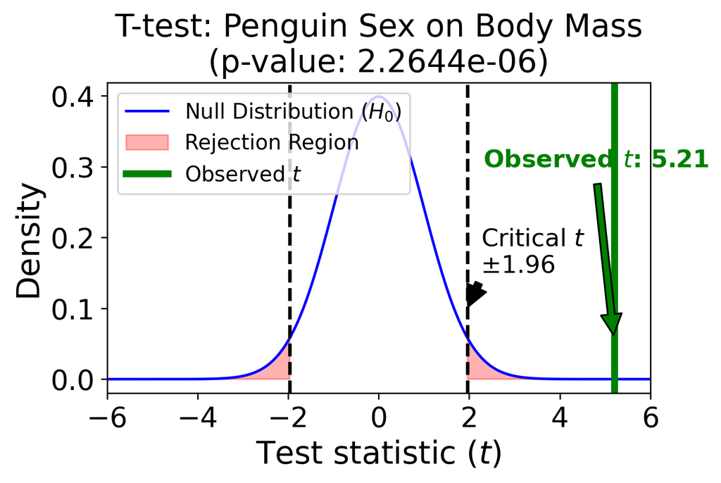

## Comparing More Than Two Means

- Use ANOVA to test differences across 3+ species
- Controls Type I error compared with multiple t-tests
- Follow significant results with post-hoc comparisons
- Interpret effect sizes (e.g., eta-squared)
- Transform multinomial to dummy for linear regression

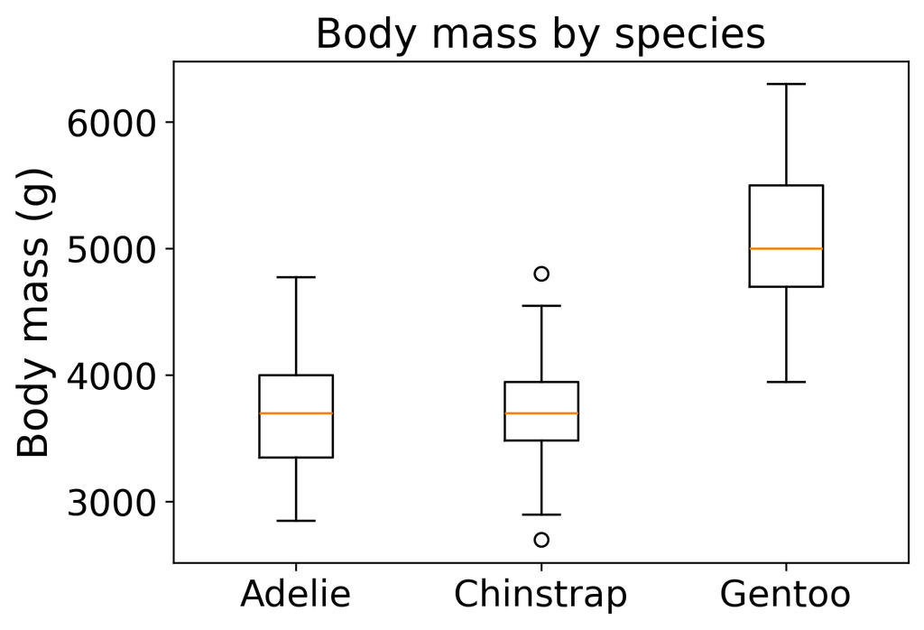

## The t-test as Linear Model

- A two-group t-test equals a linear model with a dummy variable
- Intercept equals the mean of the reference group
- The coefficient equals the mean difference between groups
- Same t-statistic, same p-value (for two-tailed tests)
- Useful for survey experiments!

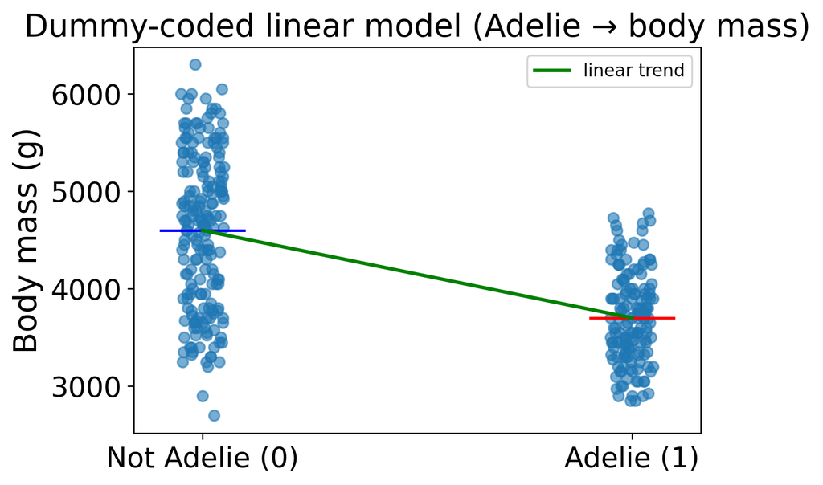

## Contingency Tables and Two-Way Tests

- Two categorical variables form a contingency table
- Example: species by island
- Chi-squared tests independence between variables
- Expected counts come from row/column margins
- Heatmaps highlight influential cells

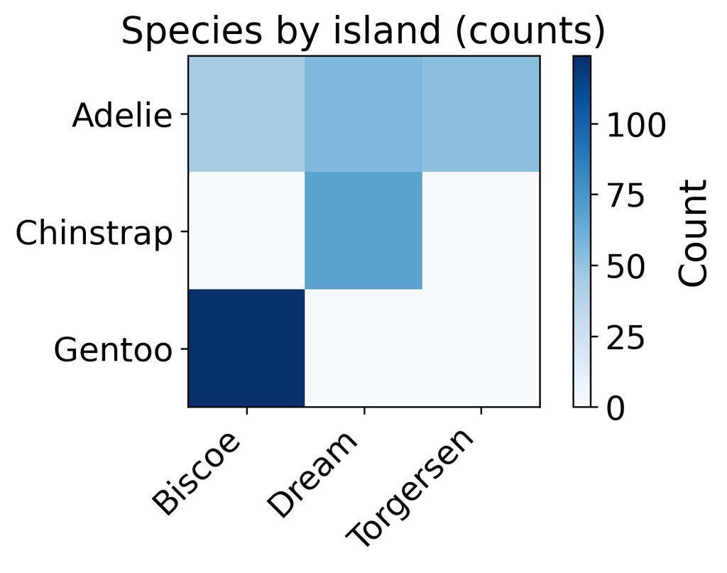

## Covariance and Correlation, Pearson’s r

- Covariance captures joint variability of two measures
- Correlation standardizes covariance to -1 to 1
- Example: bill length vs body mass
- Correlation summarizes linear association only
- Always inspect the data visually

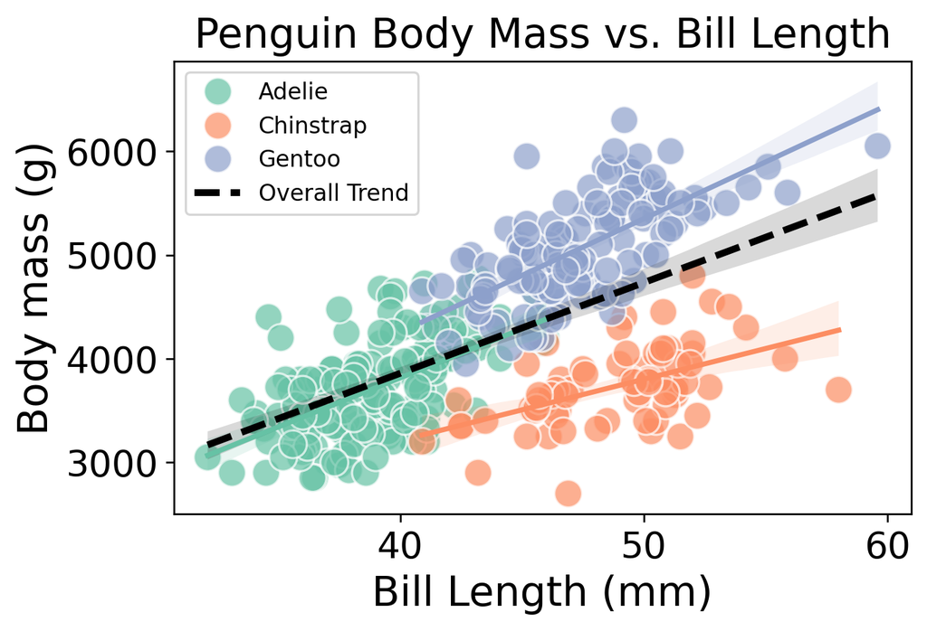

## Hypothesis Testing for Correlations

- Test whether an observed correlation differs from zero
- Use bill length vs body mass as the example
- Permutation tests are intuitive and assumption-light
- P-value is the tail area beyond the observed correlation
- Always report the effect size along with significance

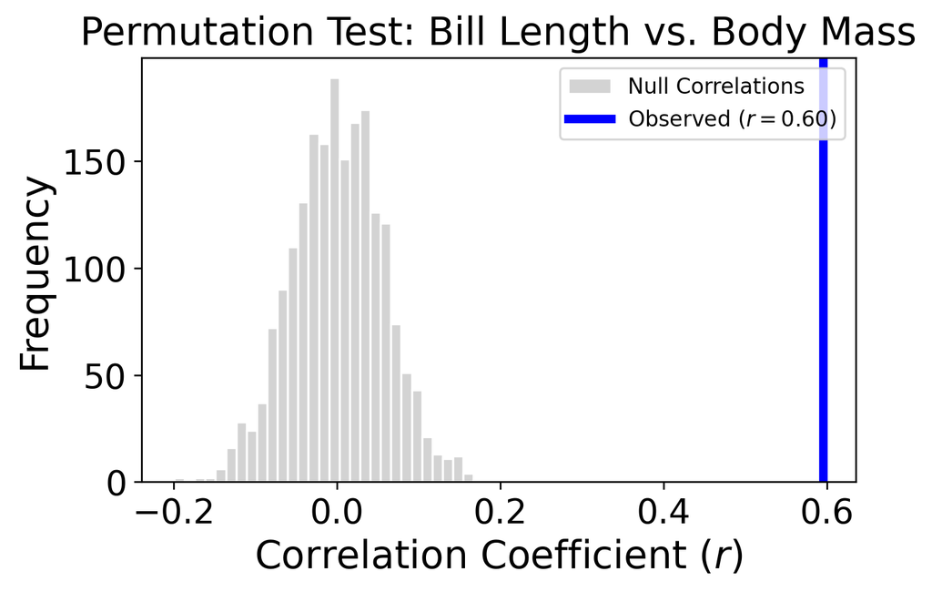

Multiple Regression Analysis (MRA)

## Gentoo Sample and Regression Line

- Use 10 random Gentoo penguins
- Outcome is body mass
- Predictor is bill length
- Fit a straight line to the sample
- Slope shows expected mass change per mm

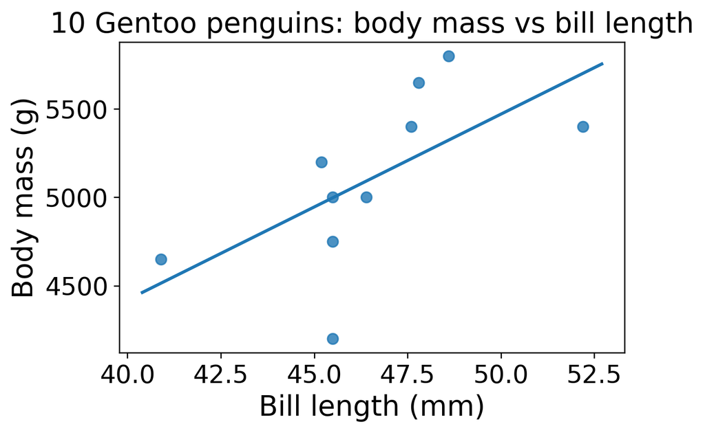

## Slope Means Change in Y per Unit X

- Slope is rise over run
- Here run is plus 1 mm bill length
- Rise is the model change in body mass
- Positive slope means y increases as x increases
- Slope units are grams per millimeter

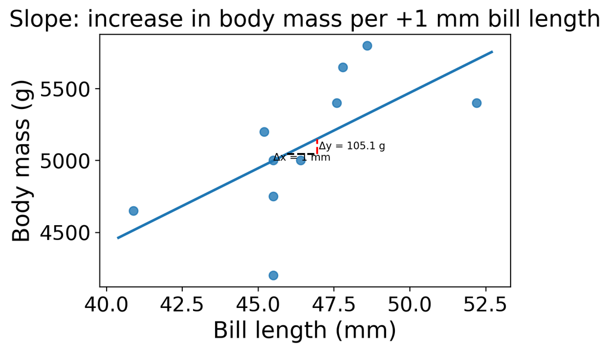

## Least Squares Residuals for All Points

- Residual equals observed minus fitted value
- Show residual for every data point
- Positive residual means point is above line
- Negative residual means point is below line
- Least squares minimizes total squared residuals

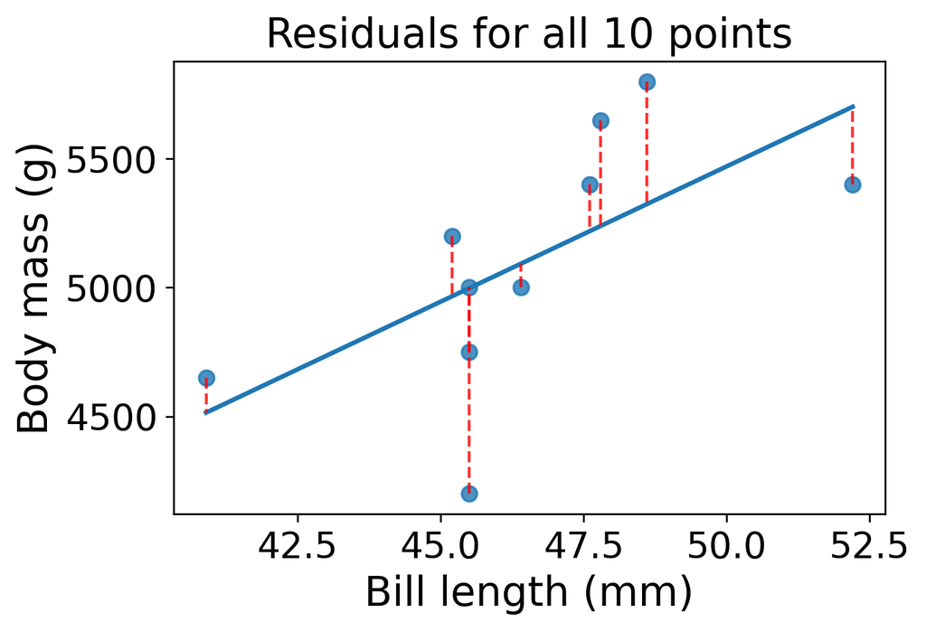

## Residuals vs Horizontal Mean Line

- Mean model uses one horizontal line
- Regression model tilts line with bill length
- Compare residual size for each model
- Smaller residual spread means better fit
- Regression usually beats mean-only baseline

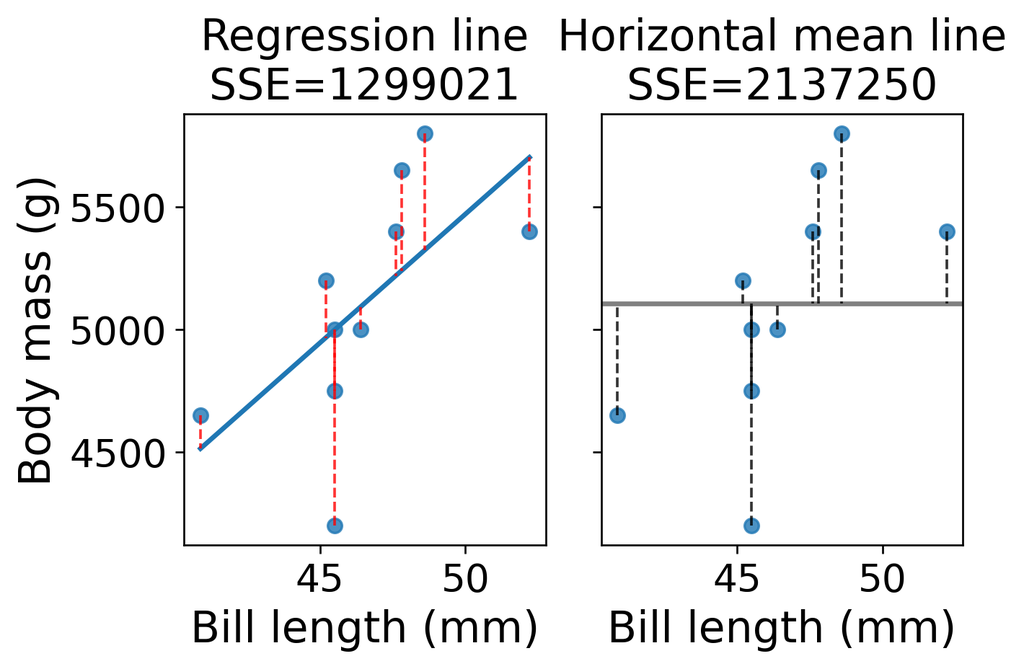

## Interpreting R Squared on the Sample

- R squared compares two error totals
- Baseline error comes from mean line
- Model error comes from regression line
- Higher R squared means more explained variance
- Here it is computed on the 10 penguins

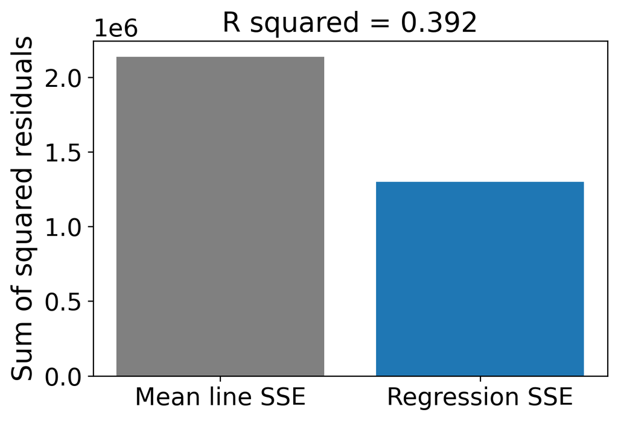

## Predictions Versus Observed Body Mass

- Predict body mass from bill length
- Compare predicted to observed values
- Perfect predictions sit on 45 degree line
- Distance from line is prediction error
- Pattern shows practical model quality

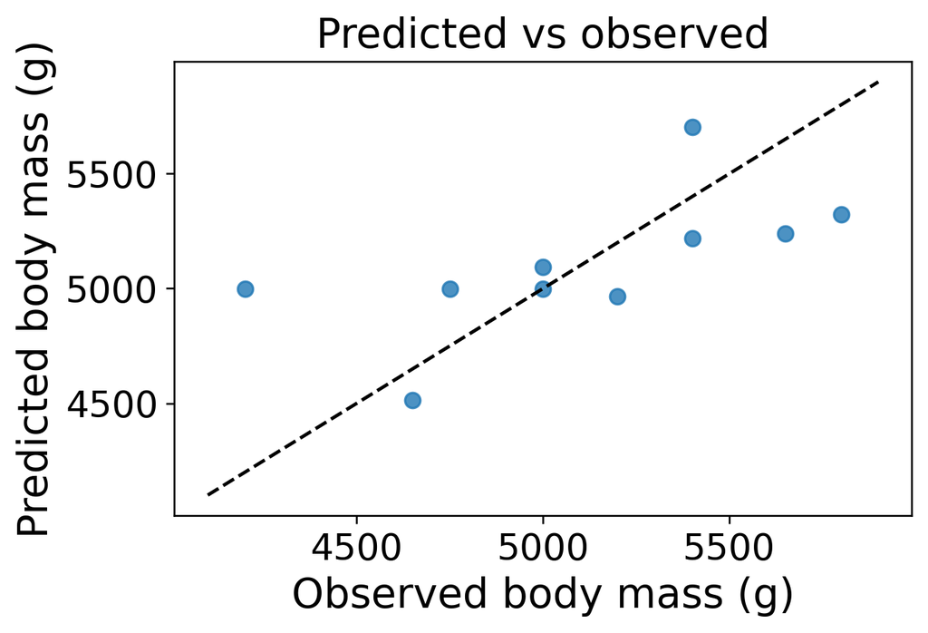

## Binary Predictor Regression with Sex

- Reuse the same 10 Gentoo penguins
- Encode sex as Female=0, Male=1
- Fit a linear regression with binary predictor
- Intercept is mean for Female group
- Slope is mean difference Male minus Female

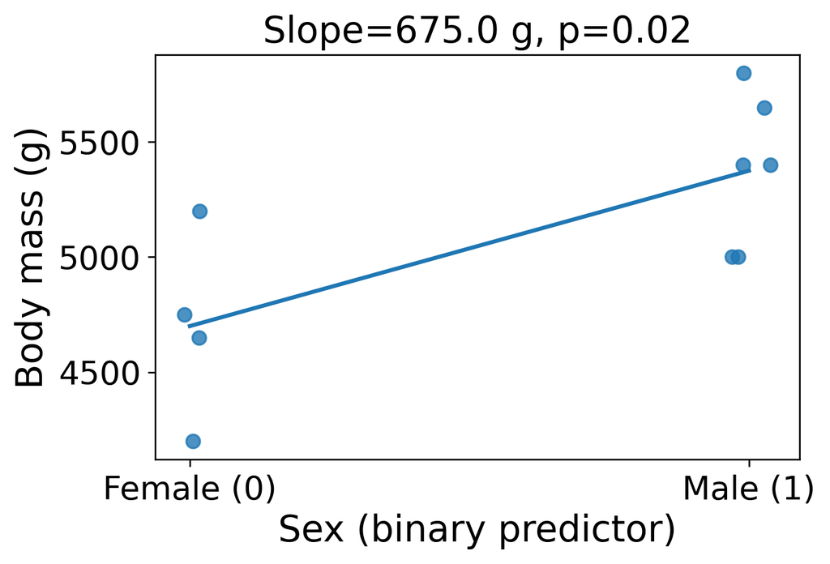

## Linear Effects from the Full Model

- Full model uses all predictors in `model.mermaid`
- Outcome is `body_mass_g`; predictors are bill length, species, and sex
- Coefficients represent linear effects while holding others constant
- Effects whose intervals avoid zero are stronger evidence

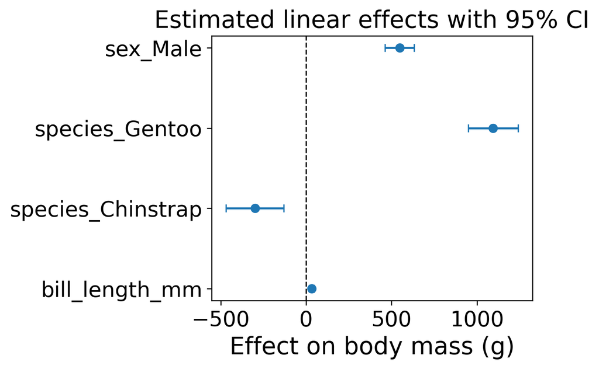

## Multiple Regression and Interpretation

- Fit one model with all predictors at the same time
- Use simple OLS matrix code with dummy-coded categorical variables
- For each coefficient, compute t statistic and p-value
- Report `R^2` to summarize overall variance explained
- Interpret each term relative to its reference category

```
                term    beta_g  p_value
0          Intercept  2169.270    0.000
1     bill_length_mm    32.537    0.000
2  species_Chinstrap  -298.766    0.001
3     species_Gentoo  1094.867    0.000
4           sex_Male   547.367    0.000

Interpretation:
- +1 mm bill length -> 32.5 g (p=1.15e-05)
- Chinstrap vs Adelie -> -298.8 g (p=0.000577)
- Gentoo vs Adelie -> 1094.9 g (p=0)
- Male vs Female -> 547.4 g (p=0)
- Model R^2 = 0.856
```

## Next steps

**Workshop 1.2, feb 24**

- Lecture notes: https://cca-cce.github.io/osm-comm/web/edu/skoc62-lecture2.html
- Workshop 1.2: https://cca-cce.github.io/osm-comm/web/edu/skoc62-workshop1.html

**References**

6, P., and C. Bellamy. 2011. *Principles of Methodology: Research Design in Social Science*. Principles of Methodology: Research Design in Social Science. SAGE Publications. https://books.google.se/books?id=IWQ0wwEACAAJ.

Djurfeldt, Göran, Rolf Larsson, and Ola Stjärnhagen. 2003. “Statistisk Verktygslåda-Samhällsvetenskaplig Orsaksanalys Med Kvantitativa Metoder.”

Trost, Jan, and Oscar Hultåker. 2016. *Enkätboken*. Femte upplagan. Lund: Studentlitteratur.